# Introduction to R

Christopher David Desjardins

August 20, 2015

# Section 1. Customizing Rstudio

Much of the Rstudio IDE is customizable. By default Rstudio has soft-wrap R sources files disabled. This might be something you wish to enable to prevent very long lines. I would recommend just breaking your lines after 80 characters or so anyways.

You can find these settings under Tools -> Global Options.

You can also change the pane layout if you want.

By default, the following layout is used. Upper Left - Code editor Bottom Left - R console Upper Right - Environment, i.e. what is currently in R and History, i.e. what commands you have run. Bottom Right - Viewer for help pages, files in current directory, graphs, and packages.

You’ll always want write code in the Code editor and not directly in the R console unless it’s something you know you’ll never want to write again!

# Section 2. R Basics

First, here are some books. - Using R for Introductory Statistics (free): http://cran.r-project.org/doc/contrib/Verzani-SimpleR.pdf - Linear models with R: http://www.amazon.com/Linear-Models-Chapman-Statistical-Science/dp/1584884258 - Extending the linear model with R: http://www.amazon.com/Extending-Linear-Model-Generalized-Nonparametric/dp/158488424X

However, there’s lot of R resources. So unless you want a printed R book you don’t need to buy one. What I do is often just Google my problem and I either hitstackoverflow or the R-help mailing list. There are also lots of wonderful blogs.

For example, http://www.statmethods.net/

For Icelandic R videos: https://www.youtube.com/channel/UClpgj8pTFS3XT5SHYWpAbrQ. These are R videos and statistics tutorials for the stats department at HÍ.

R is both a programming language and a statistics environment

To install a library in R use the install.package() function and R will figure out all it’s dependencies automatically.

```r
install.packages("irtoys")  # IRT models
install.packages("lme4")  # HLM aka mixed effects modeling, can do Rasch modeling
install.packages("lavaan")  # CFA, SEM simple output/model syntax to MPlus
install.packages("ggplot2")  # Graphing package
install.packages("psych")  # CTT, FA, http://personality-project.org/r/
install.packages("plyr")  # Data manipulation
install.packages("equate")  # Equating
```

To load a library.

```r
library("foreign")  # This is library needs to be loaded to read SPSS data
```

To list the functions in a particular package

```r
lsf.str("package:foreign")
```

```
## data.restore : function (file, print = FALSE, verbose = FALSE, env = .GlobalEnv)
## lookup.xport : function (file)
## read.arff : function (file)
## read.dbf : function (file, as.is = FALSE)
## read.dta : function (file, convert.dates = TRUE, convert.factors = TRUE, missing.type = FALSE,
##     convert.underscore = FALSE, warn.missing.labels = TRUE)
## read.epiinfo : function (file, read.deleted = FALSE, guess.broken.dates = FALSE,
##     thisyear = NULL, lower.case.names = FALSE)
## read.mtp : function (file)
## read.octave : function (file)
## read.S : function (file)
## read.spss : function (file, use.value.labels = TRUE, to.data.frame = FALSE, max.value.labels = Inf,
##     trim.factor.names = FALSE, trim_values = TRUE, reencode = NA,
##     use.missings = to.data.frame)
## read.ssd : function (libname, sectionnames, tmpXport = tempfile(), tmpProgLoc = tempfile(),
##     sascmd = "sas")
## read.systat : function (file, to.data.frame = TRUE)
## read.xport : function (file)
## write.arff : function (x, file, eol = "\n", relation = deparse(substitute(x)))
## write.dbf : function (dataframe, file, factor2char = TRUE, max_nchar = 254)
## write.dta : function (dataframe, file, version = 7L, convert.dates = TRUE, tz = "GMT",
##     convert.factors = c("labels", "string", "numeric", "codes"))
## write.foreign : function (df, datafile, codefile, package = c("SPSS", "Stata", "SAS"),
##     ...)
```

More detailed handouts, called vignettes, are available for packages.

```r
vignette()
vignette("release")  ## ggplot2 vignette
```

To find out information about a function:

```r
?read.spss  # In spite of the cavaet, I have had no issues with this function
```

To search for a keyword

```r
??item
```

What data sets are available?

```r
data()
```

Which data sets belong to irtoys?

```r
data(package = c("irtoys"))
```

To check what directory we’re working from and set it

```r
getwd()
setwd("~/Dropbox/cdd/GitHub/e411prma/data/")
```

To see what’s in that directory

```r
dir()
```

```
## [1] "introduction_R.html" "introduction_R.Rmd"
```

Import the Harry Potter pretest

```r
# "<-" this is the assignment operator
pretest <- read.csv(file = "~/Dropbox/cdd/GitHub/e411prma/data/hp_pretest.csv", na.strings = "")
# I recomend always naming objects in lowercase.
# If you want to combine words use lower.case
```

Note that pretest appears in the Environment window (UR). You can also see that by running ls() in R

```r
ls()
```

```
## [1] "pretest"
```

You can also note the History tab in the UR that includes all the commands you’ve run.

Investigate the first few cases and then the last few case.

```r
head(pretest)
```

```
##   Q1 Q2 Q3 Q4 Q5 Q6 Q7 Q8 Q9 Q10 Q11 Q12 Q13 Q14 Q15 Q16 Q17 Q18 Q19 Q20
## 1  a  b  c  d  a  a  a  c  d   c   c   c   b   a   c   a   c   c   a   c
## 2  c  b  d  c  a  d  a  c  a   a   d   c   d   a   a   a   b   c   c   b
## 3  c  a  d  c  a  a  a  a  d   a   c   d   d   c   c   d   a   b   c   d
## 4  c  a  c  c  a  a  b  a  d   a   c   a   b   c   c   d   c   a   c   d
## 5  c  b  c  c  c  a  b  a  d   c   c   d   b   a   a   d   a   b   c   a
## 6  c  a  b  c  c  b  b  c  c   b   b   c   d   a   c   c   b   c   c   d
##    Q21  Q22  Q23  Q24
## 1    c    a    b    d
## 2    b    c    d    b
## 3 <NA> <NA> <NA> <NA>
## 4    d    a    d    c
## 5    c    a    c    c
## 6    c    a    b    b
```

```r
tail(pretest)
```

```
##    Q1 Q2 Q3 Q4 Q5 Q6 Q7 Q8 Q9 Q10 Q11 Q12 Q13 Q14 Q15 Q16 Q17 Q18 Q19 Q20
## 30  c  b  c  c  c  a  a  a  d   d   c   d   d   d   b   b   a   a   a   a
## 31  c  b  c  c  c  a  c  a  d   a   c   d   c   d   c   d   a   b   a   c
## 32  c  b  c  c  c  b  b  a  d   a   c   d   c   a   b   d   a   a   c   a
## 33  c  b  c  c  a  a  a  a  d   b   c   b   a   a   b   d   a   c   a   a
## 34  c  c  c  c  c  c  b  a  d   a   c   a   d   b   b   d   c   b   d   b
## 35  c  b  d  c  a  d  c  a  d   d   b   d   d   a   c   d   a   c   b   d
##    Q21 Q22 Q23 Q24
## 30   c   a   c   d
## 31   c   a   a   c
## 32   a   c   c   d
## 33   d   a   b   d
## 34   c   c   c   a
## 35   c   a   c   d
```

To view all the data type

```r
pretest
```

```
##    Q1 Q2 Q3   Q4 Q5 Q6   Q7 Q8 Q9 Q10 Q11 Q12 Q13 Q14 Q15 Q16 Q17 Q18 Q19
## 1   a  b  c    d  a  a    a  c  d   c   c   c   b   a   c   a   c   c   a
## 2   c  b  d    c  a  d    a  c  a   a   d   c   d   a   a   a   b   c   c
## 3   c  a  d    c  a  a    a  a  d   a   c   d   d   c   c   d   a   b   c
## 4   c  a  c    c  a  a    b  a  d   a   c   a   b   c   c   d   c   a   c
## 5   c  b  c    c  c  a    b  a  d   c   c   d   b   a   a   d   a   b   c
## 6   c  a  b    c  c  b    b  c  c   b   b   c   d   a   c   c   b   c   c
## 7   c  b  c    c  a  a    a  a  d   b   c   d   b   d   c   d   a   b   c
## 8   c  b  c    c  c  a    c  a  d   b   c   d   d   b   c   d   d   a   c
## 9   c  a  b    a  a  a    c  a  b   c   d   c   b   b   c   a   b   c   c
## 10  c  b  c    c  a  a    c  a  c   a   d   d   d   c   c   c   a   a   c
## 11  c  a  c    c  d  a    b  a  d   c   c   a   c   d   c   a   c   c   c
## 12  c  b  c    c  c  a    c  a  d   b   c   d   b   b   b   d   a   a   c
## 13  c  b  b    c  c  a    c  a  c   b   d   a   d   b   b   d   c   b   c
## 14  a  b  a    c  c  c    c  b  d   c   a   b   c   c   b   b   c   b   a
```

[output cut: 57 more lines]

If you want to see a specific observation, say #20, and you want to see responses from questions 2 through 3.

```r
pretest[20,2:3]
```

```
##    Q2 Q3
## 20  b  c
```

Or if you want to see questions 1, 3, and 6 for observations 19 through 21.

```r
pretest[19:21, c(1,3,6)]
```

```
##    Q1 Q3 Q6
## 19  c  c  a
## 20  c  c  b
## 21  c  b  a
```

To get information about the data set and the variable types

```r
str(pretest)
```

```
## 'data.frame':    35 obs. of  24 variables:
##  $ Q1 : Factor w/ 2 levels "a","c": 1 2 2 2 2 2 2 2 2 2 ...
##  $ Q2 : Factor w/ 3 levels "a","b","c": 2 2 1 1 2 1 2 2 1 2 ...
##  $ Q3 : Factor w/ 4 levels "a","b","c","d": 3 4 4 3 3 2 3 3 2 3 ...
##  $ Q4 : Factor w/ 4 levels "a","b","c","d": 4 3 3 3 3 3 3 3 1 3 ...
##  $ Q5 : Factor w/ 4 levels "a","b","c","d": 1 1 1 1 3 3 1 3 1 1 ...
##  $ Q6 : Factor w/ 4 levels "a","b","c","d": 1 4 1 1 1 2 1 1 1 1 ...
##  $ Q7 : Factor w/ 3 levels "a","b","c": 1 1 1 2 2 2 1 3 3 3 ...
##  $ Q8 : Factor w/ 4 levels "a","b","c","d": 3 3 1 1 1 3 1 1 1 1 ...
##  $ Q9 : Factor w/ 4 levels "a","b","c","d": 4 1 4 4 4 3 4 4 2 3 ...
##  $ Q10: Factor w/ 4 levels "a","b","c","d": 3 1 1 1 3 2 2 2 3 1 ...
##  $ Q11: Factor w/ 4 levels "a","b","c","d": 3 4 3 3 3 2 3 3 4 4 ...
##  $ Q12: Factor w/ 4 levels "a","b","c","d": 3 3 4 1 4 3 4 4 3 4 ...
##  $ Q13: Factor w/ 4 levels "a","b","c","d": 2 4 4 2 2 4 2 4 2 4 ...
##  $ Q14: Factor w/ 4 levels "a","b","c","d": 1 1 3 3 1 1 4 2 2 3 ...
##  $ Q15: Factor w/ 4 levels "a","b","c","d": 3 1 3 3 1 3 3 3 3 3 ...
##  $ Q16: Factor w/ 4 levels "a","b","c","d": 1 1 4 4 4 3 4 4 1 3 ...
##  $ Q17: Factor w/ 4 levels "a","b","c","d": 3 2 1 3 1 2 1 4 2 1 ...
##  $ Q18: Factor w/ 3 levels "a","b","c": 3 3 2 1 2 3 2 1 3 1 ...
##  $ Q19: Factor w/ 4 levels "a","b","c","d": 1 3 3 3 3 3 3 3 3 3 ...
##  $ Q20: Factor w/ 4 levels "a","b","c","d": 3 2 4 4 1 4 2 4 2 4 ...
##  $ Q21: Factor w/ 4 levels "a","b","c","d": 3 2 NA 4 3 3 3 1 1 3 ...
##  $ Q22: Factor w/ 4 levels "a","b","c","d": 1 3 NA 1 1 1 1 1 4 3 ...
##  $ Q23: Factor w/ 4 levels "a","b","c","d": 2 4 NA 4 3 2 4 3 1 4 ...
##  $ Q24: Factor w/ 4 levels "a","b","c","d": 4 2 NA 3 3 2 2 1 2 1 ...
```

Notice, that these are being treated as factors.

To get the name of all the variables

```r
names(pretest)
```

```
##  [1] "Q1"  "Q2"  "Q3"  "Q4"  "Q5"  "Q6"  "Q7"  "Q8"  "Q9"  "Q10" "Q11"
## [12] "Q12" "Q13" "Q14" "Q15" "Q16" "Q17" "Q18" "Q19" "Q20" "Q21" "Q22"
## [23] "Q23" "Q24"
```

To save the data to a text file named *pretest.txt* in your working directory

```r
write.table(pretest, file = "pretest.txt")
```

and to read the file back in

```r
read.table(file="pretest.txt")
```

We should always read data into an object

```r
pretest.tmp <- read.table(file="pretest.txt")
```

Similar functions exist to read data directly from CSV files, SAS files, etc. Check out the *foreign* package.

To get summary of the pretest data

```r
summary(pretest)
```

```
##  Q1     Q2     Q3        Q4     Q5     Q6        Q7     Q8     Q9
##  a: 2   a:10   a: 1   a   : 1   a:12   a:24   a   :13   a:26   a: 1
##  c:33   b:24   b: 6   b   : 1   b: 2   b: 5   b   :11   b: 2   b: 1
##         c: 1   c:24   c   :31   c:20   c: 3   c   :10   c: 6   c: 6
##                d: 4   d   : 1   d: 1   d: 3   NA's: 1   d: 1   d:27
##                       NA's: 1
##  Q10    Q11    Q12    Q13    Q14    Q15    Q16    Q17    Q18    Q19
##  a:16   a: 2   a: 9   a: 4   a:12   a: 4   a: 8   a:18   a:10   a:11
##  b:11   b: 6   b: 2   b:11   b:10   b:13   b: 2   b: 7   b:12   b: 5
##  c: 5   c:21   c: 8   c: 7   c: 4   c:16   c: 4   c: 9   c:13   c:18
##  d: 3   d: 6   d:16   d:13   d: 9   d: 2   d:21   d: 1          d: 1
##
##  Q20      Q21       Q22       Q23       Q24
##  a: 7   a   :11   a   :21   a   : 5   a   : 5
##  b: 5   b   : 1   b   : 3   b   : 7   b   : 9
##  c: 6   c   :20   c   : 5   c   :17   c   : 9
##  d:17   d   : 2   d   : 5   d   : 5   d   :11
##         NA's: 1   NA's: 1   NA's: 1   NA's: 1
```

To access a variable in the data.frame use the “$” symbol.

```r
pretest$Q1  # fyi, R is case sensitive
```

```
##  [1] a c c c c c c c c c c c c a c c c c c c c c c c c c c c c c c c c c c
## Levels: a c
```

To create a table of this.

```r
table(pretest$Q1)
```

```
##
##  a  c
##  2 33
```

Let’s a unique ID variable to this data set

```r
pretest$id <- 1:nrow(pretest)  # nrow(), number of rows in the data.frame
head(pretest)
```

```
##   Q1 Q2 Q3 Q4 Q5 Q6 Q7 Q8 Q9 Q10 Q11 Q12 Q13 Q14 Q15 Q16 Q17 Q18 Q19 Q20
## 1  a  b  c  d  a  a  a  c  d   c   c   c   b   a   c   a   c   c   a   c
## 2  c  b  d  c  a  d  a  c  a   a   d   c   d   a   a   a   b   c   c   b
## 3  c  a  d  c  a  a  a  a  d   a   c   d   d   c   c   d   a   b   c   d
## 4  c  a  c  c  a  a  b  a  d   a   c   a   b   c   c   d   c   a   c   d
## 5  c  b  c  c  c  a  b  a  d   c   c   d   b   a   a   d   a   b   c   a
## 6  c  a  b  c  c  b  b  c  c   b   b   c   d   a   c   c   b   c   c   d
##    Q21  Q22  Q23  Q24 id
## 1    c    a    b    d  1
## 2    b    c    d    b  2
## 3 <NA> <NA> <NA> <NA>  3
## 4    d    a    d    c  4
## 5    c    a    c    c  5
## 6    c    a    b    b  6
```

What if we found out subject 1 should had a ‘b’ Q3 not ‘c’

```r
pretest[pretest$id == 1,]
```

```
##   Q1 Q2 Q3 Q4 Q5 Q6 Q7 Q8 Q9 Q10 Q11 Q12 Q13 Q14 Q15 Q16 Q17 Q18 Q19 Q20
## 1  a  b  c  d  a  a  a  c  d   c   c   c   b   a   c   a   c   c   a   c
##   Q21 Q22 Q23 Q24 id
## 1   c   a   b   d  1
```

```r
pretest[pretest$id == 1, "Q3"]
```

```
## [1] c
## Levels: a b c d
```

```r
pretest[pretest$id == 1, "Q3"] <- "b"
pretest[pretest$id == 1, "Q3"]
```

```
## [1] b
## Levels: a b c d
```

We can use the psych library to get even more information

```r
library("psych")
?describe
describe(pretest)  # asterisks indicate factors
```

```
##      vars  n  mean    sd median trimmed   mad min max range  skew kurtosis
## Q1*     1 35  1.94  0.24      2    2.00  0.00   1   2     1 -3.65    11.68
## Q2*     2 35  1.74  0.51      2    1.76  0.00   1   3     2 -0.38    -0.53
## Q3*     3 35  2.86  0.65      3    2.86  0.00   1   4     3 -0.50     0.64
## Q4*     4 34  2.94  0.42      3    3.00  0.00   1   4     3 -2.72    12.03
## Q5*     5 35  2.29  0.99      3    2.31  0.00   1   4     3 -0.39    -1.60
## Q6*     6 35  1.57  0.98      1    1.38  0.00   1   4     3  1.45     0.72
## Q7*     7 34  1.91  0.83      2    1.89  1.48   1   3     2  0.16    -1.57
## Q8*     8 35  1.49  0.89      1    1.34  0.00   1   4     3  1.39     0.38
## Q9*     9 35  3.69  0.68      4    3.83  0.00   1   4     3 -2.33     5.43
## Q10*   10 35  1.86  0.97      2    1.72  1.48   1   4     3  0.83    -0.45
## Q11*   11 35  2.89  0.76      3    2.93  0.00   1   4     3 -0.61     0.31
## Q12*   12 35  2.89  1.25      3    2.97  1.48   1   4     3 -0.57    -1.39
## Q13*   13 35  2.83  1.07      3    2.90  1.48   1   4     3 -0.23    -1.38
## Q14*   14 35  2.29  1.20      2    2.24  1.48   1   4     3  0.35    -1.47
## Q15*   15 35  2.46  0.78      3    2.48  1.48   1   4     3 -0.22    -0.58
## Q16*   16 35  3.09  1.27      4    3.21  0.00   1   4     3 -0.83    -1.14
## Q17*   17 35  1.80  0.93      1    1.72  0.00   1   4     3  0.60    -1.14
## Q18*   18 35  2.09  0.82      2    2.10  1.48   1   3     2 -0.15    -1.53
## Q19*   19 35  2.26  0.95      3    2.28  0.00   1   4     3 -0.31    -1.52
## Q20*   20 35  2.94  1.21      3    3.03  1.48   1   4     3 -0.57    -1.34
## Q21*   21 34  2.38  1.02      3    2.39  0.00   1   4     3 -0.45    -1.43
## Q22*   22 34  1.82  1.17      1    1.68  0.00   1   4     3  0.89    -0.92
## Q23*   23 34  2.65  0.92      3    2.68  0.74   1   4     3 -0.42    -0.71
## Q24*   24 34  2.76  1.07      3    2.82  1.48   1   4     3 -0.25    -1.30
## id     25 35 18.00 10.25     18   18.00 13.34   1  35    34  0.00    -1.30
##        se
## Q1*  0.04
## Q2*  0.09
## Q3*  0.11
## Q4*  0.07
## Q5*  0.17
## Q6*  0.17
## Q7*  0.14
## Q8*  0.15
## Q9*  0.11
## Q10* 0.16
## Q11* 0.13
## Q12* 0.21
## Q13* 0.18
## Q14* 0.20
## Q15* 0.13
## Q16* 0.21
## Q17* 0.16
## Q18* 0.14
## Q19* 0.16
## Q20* 0.20
## Q21* 0.17
## Q22* 0.20
## Q23* 0.16
## Q24* 0.18
## id   1.73
```

But is the appropriate for this kind of data?

Conditional tables, these are especially useful for factors

```r
table(pretest$Q1,pretest$Q24)
```

```
##
##     a b c d
##   a 0 0 0 2
##   c 5 9 9 9
```

How many levels of factor are there and lists the levels

```r
nlevels(pretest$Q2)
```

```
## [1] 3
```

```r
levels(pretest$Q2)
```

```
## [1] "a" "b" "c"
```

Completely remove a variable

```r
pretest$Q15 <- NULL
```

# Section 3. Graphing

Graphing can be accomplishing using just the R base libraries. But, graphing is greatly expanded with ggplot2. I’ll just show you with ggplot2.

## Scatterplots

The data I will use comes from the mpg dataset. This has miles per gallon.

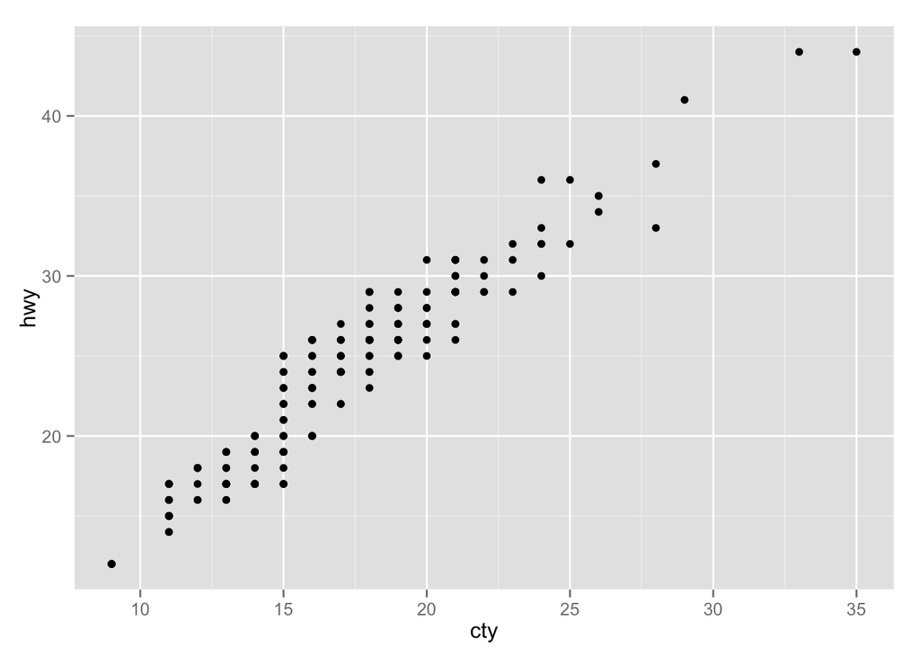

```r
library(ggplot2)
qplot(x = cty, y = hwy, data = mpg)
```

That command is identical to the previous one.

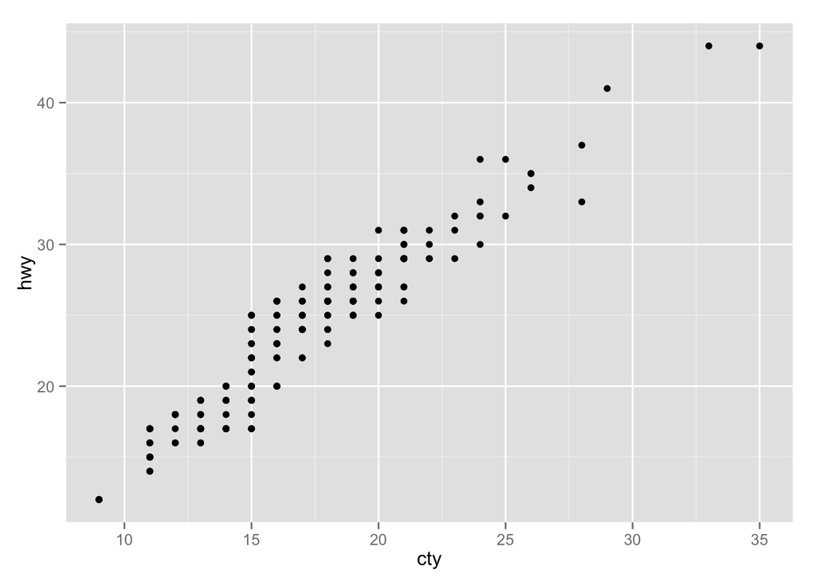

```r
ggplot(aes(x = cty, y = hwy), data = mpg) + geom_point()
```

The advantage of the second line is that you’ll often build up and change graphs.

```r
g0 <- ggplot(aes(x = cty, y = hwy), data = mpg)
g0 + geom_point() + theme_bw()  # let's give it a black and white theme
g0 + geom_point(col = "orange") + theme_bw()  # bw theme and orange points
(g1 <- g0 + geom_point(col = "orange", shape = 2) +
  theme_bw())  # bw theme and orange triangles, () echo
(g1 <- g0 + geom_point(aes(colour = manufacturer), shape = 2) +
   theme_bw())
```

Add a best fit

```r
(g2 <- g1 + stat_smooth(aes(color = manufacturer),method = "lm", formula = y ~ x))
```

Continue to modify the graph and polish it a little bit

```r
# Continue to modify the graph and polishing it a little
g2 + xlab("city miles per gallon") + ylab("highway miles per gallon") +
  scale_color_brewer(palette = "Set1") +
  theme(legend.position = "bottom") +
  ggtitle("Highway Mileage vs. City Mileage")
```

This is how to make box plots.

```r
ggplot(aes(y = hwy, x = manufacturer), data = mpg) + geom_boxplot()
ggplot(aes(y = hwy, x = manufacturer), data = mpg) +
  geom_boxplot(aes(fill = manufacturer), outlier.color = "green" )
```

Here are some marginal plot of highway mileage

```r
ggplot(data = mpg, aes(hwy)) + geom_histogram(fill="white", color = "red") +
  xlab("Highway Mileage") + ylab("Frequency")

ggplot(data = mpg, aes(hwy)) + geom_histogram(fill="white", color = "red") +
  xlab("Highway Mileage") + ylab("Frequency") + facet_grid(.~class)

ggplot(data = mpg, aes(hwy)) + geom_histogram(aes(fill=class, color = class)) +
  xlab("Highway Mileage") + ylab("Frequency") + facet_grid(manufacturer~class)
```

Extra plotting help visit: http://docs.ggplot2.org/current/. Lots of great information is available there.

# Section 4. Regression and ANOVA

```r
# t-test
t.test(ACT_MATH~GENDER, data = pretest)

# As a regression
m0 <- lm(ACT_MATH ~ GENDER, data = pretest)
summary(m0)

pretest$white <- ifelse(pretest$ETHDESCR == "White     ", "White","Non-White")
table(pretest$white)
pretest$red.ethnic <- ifelse(pretest$ETHDESCR == "White     ", "White",
                            ifelse(pretest$ETHDESCR ==  "Black     ", "Black", "Other"))

red.ethnic <- ifelse(pretest$ETHDESCR == "White     ", "White",
                     ifelse(pretest$ETHDESCR ==  "Black     ", "Black", "Other"))

# Which is of course also a one-factor ANOVA
anova(m0)

# Note, that the p-values were close but not identical.
t.test(ACT_MATH~GENDER, data = pretest, var.equal = FALSE)

# m0 contains information
str(m0)  # it's a list of 14 items

# Can access these directly
m0$coef
m0$residuals

# Or through R commands
coef(m0)
print(residuals(m0), digits = 2)

# You can get a lot of diagnostic information from plotting model
plot(m0)

# Simple linear regression
m1 <- lm(CUM_GPA ~ ACT_TOTL, data = pretest)
summary(m1)
plot(m1)  # model looks pretty reasonable

# Box-Cox transformation
library(MASS)
boxcox(m1)

# Multiple regression
m2 <- lm(CUM_GPA ~ HSPR + STATGRAD, data = pretest)
summary(m2)

# ANOVA
m3 <- lm(CUM_GPA ~ GENDER + ETHDESCR + GENDER*ETHDESCR, data = pretest)
anova(m3)

# Fit the model with everything in it except STATGRAD and id
m4 <- lm(CUM_GPA ~ . - id - STATGRAD, data = pretest)
summary(m4)

# Do stepwise selection, but can't have missing data
# Omit missing data
pretest.m <- na.omit(pretest)
m5 <- lm(CUM_GPA ~ . - id - STATGRAD, data = pretest.m)

# Stepwise (unwise) selection
step.mod <- stepAIC(m5)
summary(step.mod)
```